# Effect of multi-collinearity

Omkar Shetty

03/11/2020

The objective is to understand the impact that correlated freatures have on predictions when used with different algorithms.

## Setting Everything Up

Here we create a dataset for the model

```r
# Define a config

config <- list(
    N = 5000,        # total no of rows
    const = 30,      # constant for dependent variable
    par_a = 15,      # coefficiant for feature a
    par_b = 0.3,     # coefficient for feature b
    par_c = 8,       # coefficient for feature c
    train_n = 4000   # No of rows used for training the model
)

set.seed(123)
```

Creating a simulated dataset. This dataset will be used to build and test the different models. For this initial example, all features are numeric and no data are missing.

```r
ttl_dat <- data.table(feat_a = runif(n = config$N, min = 1, max = 10),
                      feat_b = runif(n = config$N, min = 1, max = 100),
                      feat_c = runif(n = config$N, min = 10, max = 20))

str(ttl_dat)
```

```
## Classes 'data.table' and 'data.frame':   5000 obs. of  3 variables:
##  $ feat_a: num  3.59 8.09 4.68 8.95 9.46 ...
##  $ feat_b: num  25.6 99 72 65.5 24.8 ...
##  $ feat_c: num  13.1 13.2 18.7 13.3 11.3 ...
##  - attr(*, ".internal.selfref")=<externalptr>
```

Define a correlated feature. We will try two options - a. feature with a perfect correlation b. feature with a strong correlation

```r
# Defining the feature with a perfect correlation

ttl_dat[,feat_a_dup := feat_a ]
ttl_dat[,cor(feat_a, feat_a_dup)]
```

```
## [1] 1
```

```r
# Defining the second feature with a strong correlation

ttl_dat[,feat_a_cor := feat_a + rnorm(n = config$N, mean = 0, sd = 1)]
ttl_dat[,cor(feat_a, feat_a_cor)]
```

```
## [1] 0.9317696
```

Defining a dependent variable (to be predicted) - we start with a linear form

```r
ttl_dat[,y_act := config$const +
                  rnorm(n = config$N ,mean = config$par_a*feat_a, sd = 10) +
                  rnorm(n = config$N ,mean = config$par_b*feat_b, sd = 10) +
                  rnorm(n = config$N ,mean = config$par_c*feat_c, sd = 10) ]
```

Now that the dataset is ready, we move towards modelling - starting by splitting data into train and test

```r
train_id <- sample(x = config$N, size = config$train_n, replace = F)
train_dat <- ttl_dat[train_id]
test_dat <- ttl_dat[!train_id]
```

Starting the model build with some linear models - which are known to be susceptible to multicollinearity

```r
# Linear Model

lm_fit1 <- lm(formula = 'y_act ~ feat_a + feat_b + feat_c', data = train_dat)

summary(lm_fit1)
```

```
##
## Call:
## lm(formula = "y_act ~ feat_a + feat_b + feat_c", data = train_dat)
##
## Residuals:
##     Min      1Q  Median      3Q     Max
## -56.761 -12.022   0.321  11.472  65.996
##
## Coefficients:
##              Estimate Std. Error t value Pr(>|t|)
## (Intercept) 30.620286   1.646938   18.59   <2e-16 ***
## feat_a      14.966455   0.106009  141.18   <2e-16 ***
## feat_b       0.298483   0.009659   30.90   <2e-16 ***
## feat_c       7.958398   0.095390   83.43   <2e-16 ***
## ---
## Signif. codes:  0 '***' 0.001 '**' 0.01 '*' 0.05 '.' 0.1 ' ' 1
##
## Residual standard error: 17.35 on 3996 degrees of freedom
## Multiple R-squared:  0.8729, Adjusted R-squared:  0.8728
## F-statistic:  9149 on 3 and 3996 DF,  p-value: < 2.2e-16
```

As is seen by the model summary, the linear model was really successful in recovering the coefficients (which is not surprising). We also see the model performance on the test data.

```r
test_dat[,y_lm1_pred := predict(object = lm_fit1, newdata = test_dat)]
test_dat[,Metrics::rmse(actual = y_act, predicted = y_lm1_pred)]
```

```
## [1] 17.02155
```

Next we include one of the correlated features (the non perfect one) and repeat the same exercise.

```r
# Linear Model - Take 2

lm_fit2 <- lm(formula = 'y_act ~ feat_a + feat_b + feat_c + feat_a_cor', data = train_dat)
summary(lm_fit2)
```

```
##
## Call:
## lm(formula = "y_act ~ feat_a + feat_b + feat_c + feat_a_cor",
##     data = train_dat)
##
## Residuals:
##     Min      1Q  Median      3Q     Max
## -56.768 -12.039   0.291  11.488  66.108
##
## Coefficients:
##              Estimate Std. Error t value Pr(>|t|)
## (Intercept) 30.609148   1.647513  18.579   <2e-16 ***
## feat_a      15.050897   0.291111  51.702   <2e-16 ***
## feat_b       0.298581   0.009665  30.893   <2e-16 ***
## feat_c       7.958771   0.095408  83.418   <2e-16 ***
## feat_a_cor  -0.084571   0.271532  -0.311    0.755
## ---
## Signif. codes:  0 '***' 0.001 '**' 0.01 '*' 0.05 '.' 0.1 ' ' 1
##
## Residual standard error: 17.36 on 3995 degrees of freedom
## Multiple R-squared:  0.8729, Adjusted R-squared:  0.8728
## F-statistic:  6861 on 4 and 3995 DF,  p-value: < 2.2e-16
```

In this instance, there is a minor change in the coefficient for feat_a, but the model performance as such (as seen by the R squared) doesnt really get impacted all that much.

Also checking the VIF to ensure multicollinearity.

```r
car::vif(lm_fit2)
```

```
##     feat_a     feat_b     feat_c feat_a_cor
##   7.541841   1.001146   1.000550   7.541161
```

We also verify using the predictions on the test dataset.

```r
test_dat[,y_lm2_pred := predict(object = lm_fit2, newdata = test_dat)]
test_dat[,Metrics::rmse(actual = y_act, predicted = y_lm2_pred)]
```

```
## [1] 17.0195
```

## Random Forests

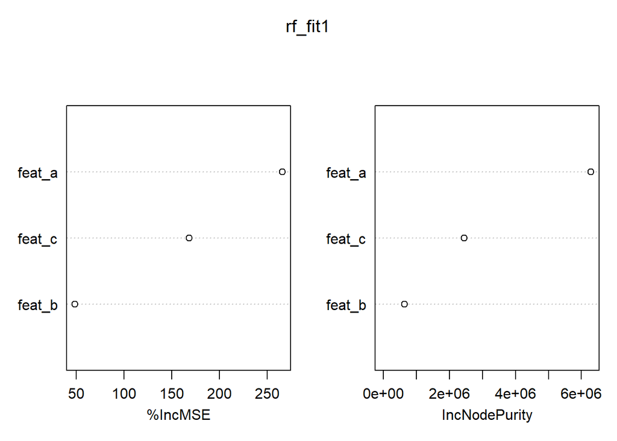

```r
rf_fit1 = randomForest(y_act ~ feat_a + feat_b + feat_c ,
                       data=train_dat,
                       ntree=100,
                       mtry=2,
                       importance=TRUE)

varImpPlot(rf_fit1)
```

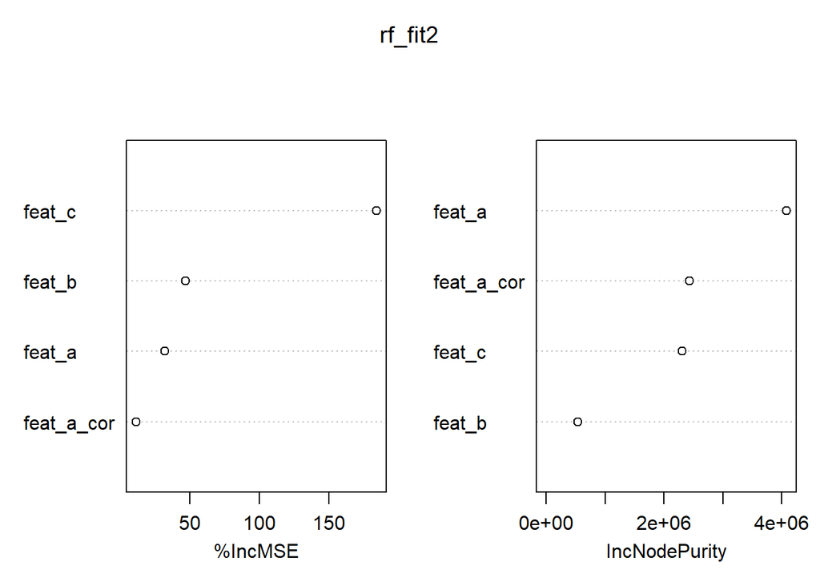

```r
rf_fit2 = randomForest(y_act ~ feat_a + feat_b + feat_c + feat_a_cor,
                       data=train_dat,
                       ntree=100,
                       mtry=2,
                       importance=TRUE)

varImpPlot(rf_fit2)
```

## XGBoost Models

Build an xgboost model

```r
feats <- c('feat_a','feat_b','feat_c')

train_mat <- data.matrix(train_dat[,..feats,with = F])
test_mat <- data.matrix(test_dat[,..feats,with = F])

fit <- xgboost::xgboost(data = train_mat,
                        label = train_dat$y_act,
                        nrounds = 5000,
                        silent = T,
                        print_every_n = 200)
```

[output not shown]

```r
pred <- predict(fit, test_mat)

test_dat[,y_pred := pred]

Metrics::rmse(actual = test_dat$y_act,predicted = test_dat$y_pred)
```

```
## [1] 19.82808
```

```r
xgboost::xgb.importance(model = fit)
```

```
##    Feature       Gain     Cover Frequency
## 1:  feat_a 0.68810711 0.3369348  0.419512
## 2:  feat_c 0.25147335 0.3280511  0.275346
## 3:  feat_b 0.06041954 0.3350141  0.305142
```

```r
feats <- c('feat_a','feat_b','feat_c','feat_a_cor')

train_mat <- data.matrix(train_dat[,..feats,with = F])
test_mat <- data.matrix(test_dat[,..feats,with = F])

fit <- xgboost::xgboost(data = train_mat,
                        label = train_dat$y_act,
                        nrounds = 5000,
                        silent = T,
                        print_every_n = 200)
```

[output not shown]

```r
pred <- predict(fit, test_mat)

test_dat[,y_pred := pred]

Metrics::rmse(actual = test_dat$y_act,predicted = test_dat$y_pred)
```

```
## [1] 19.99026
```

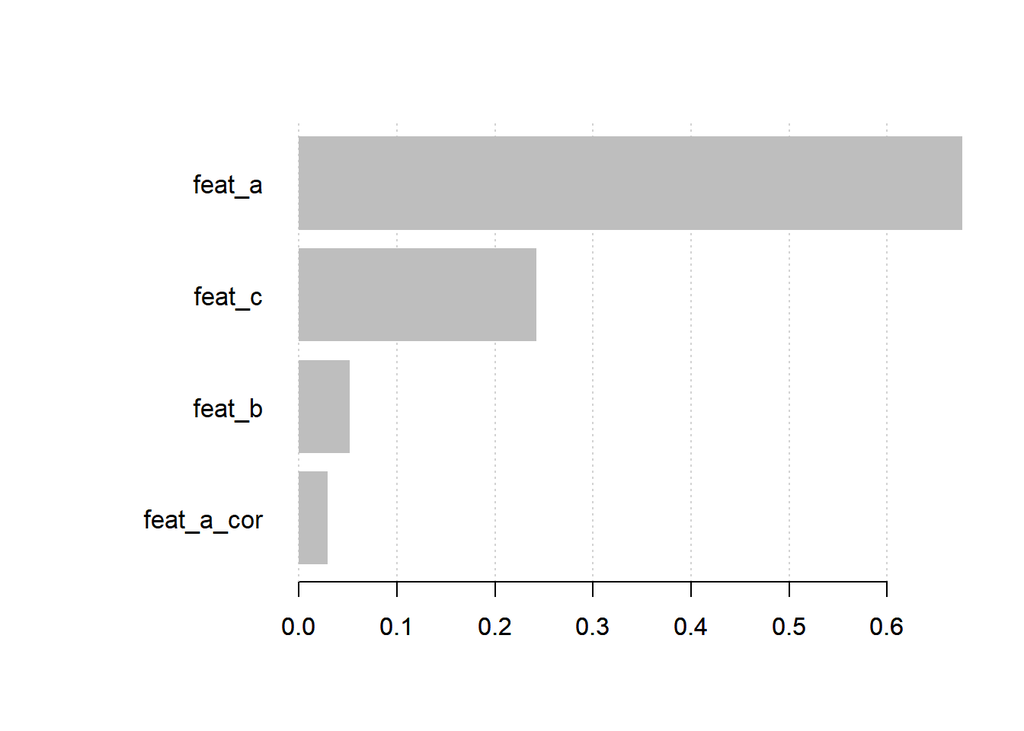

```r
xgboost::xgb.plot.importance(xgb.importance(model = fit))
```